# Exploring the BRFSS data

## Setup

### Set directory

```r
setwd("/Users/davidmclaughlin/Documents/Programming/Statistics_with_R/Intro_to_Probability_and_Data/BRFSS_data_project")
```

### Load packages

```r
library(ggplot2)
library(dplyr)
library(forcats)
library(usmap)
library(ggmap)
library(maps)
```

```r
load("brfss2013.RData")
```

## Part 1: Data

The Behavioral Risk Factor Surveillance System (BRFSS) is a collection of state-level data about U.S. residents regarding their health-related risk behaviors, chronic health conditions, and use of preventive services. BRFSS is based on more than 400,000 adult interviews conducted by telephone each year. This project analyzes data from 2013.

## Part 2: Research questions

**Research quesion 1:** Which states had the highest and lowest instances of poor physical health heatlh and poor mental health? (variables: _state, physhlth, menthlth)

**Research quesion 2:** Which states had the highest and lowest proportion of people ages 18-64 without insurance and is there a relationship between having insurance and experiencing poor physical health? (variables: X_state, X_hcvu651, physhlth)

**Research quesion 3:** Do married people have more or fewer number of days of poor mental health? (variables: marital, menthlth)

## Part 3: Exploratory data analysis

**Research quesion 1:** Which states had the highest and lowest instances of poor physical health heatlh and poor mental health? (variables: _state, physhlth, menthlth)

```r
brfphlth <- brfss2013 %>%
    select(X_state, physhlth) %>%
    group_by(X_state) %>%
    summarise(sum(physhlth, na.rm = TRUE))

brfstates <- brfss2013 %>%
    group_by(X_state) %>%
    count(X_state)

brfphlth <- as.data.frame(brfphlth)
brfstates <- as.data.frame(brfstates)

statesphlthtemp <- merge(brfphlth, brfstates)

statesphlth <- statesphlthtemp[-c(1,2), ]

statesphlth <- statesphlth %>%
    rename("State" = "X_state", "Poor_Phys_Hlth" = "sum(physhlth, na.rm = TRUE)", "Total_Records" = "n") %>%
    mutate_at(vars(Poor_Phys_Hlth, Total_Records), as.numeric)

statesphlth$Poor_Phys_Hlth_Proportion <- (statesphlth$Poor_Phys_Hlth/statesphlth$Total_Records)

st_crosswalk <- tibble(State = state.name) %>%
   bind_cols(tibble(Abb = state.abb)) %>%
   bind_rows(tibble(State = "District of Columbia", Abb = "DC")) %>%
   bind_rows(tibble(State = "Puerto Rico", Abb = "PR")) %>%
   bind_rows(tibble(State = "Guam", Abb = "GU"))

statesphlthmerge <- left_join(statesphlth, st_crosswalk, by = "State")
statesphlth <- statesphlthmerge[, c(5, 2, 3, 4)]

statesphlth <- statesphlth %>%
    rename(State = Abb) %>%
    filter(State != "GU" & State != "PR") %>%
    arrange(desc(Poor_Phys_Hlth_Proportion))

statesphlth
```

```
##    State Poor_Phys_Hlth Total_Records Poor_Phys_Hlth_Proportion
## 1     AL          37129          6505                  5.707763
## 2     WV          33112          5899                  5.613155
## 3     KY          60876         10877                  5.596764
## 4     TN          32532          5815                  5.594497
## 5     MS          39964          7453                  5.362136
## 6     AR          27957          5268                  5.306948
## 7     AZ          21932          4253                  5.156830
## 8     FL         172529         33668                  5.124421
## 9     OK          41830          8244                  5.073993
## 10    LA          26116          5215                  5.007862
## 11    NM          44016          9316                  4.724775
## 12    NC          41538          8860                  4.688262
## 13    MO          33248          7118                  4.670975
## 14    SC          48633         10717                  4.537930
```

[output cut: 37 more lines]

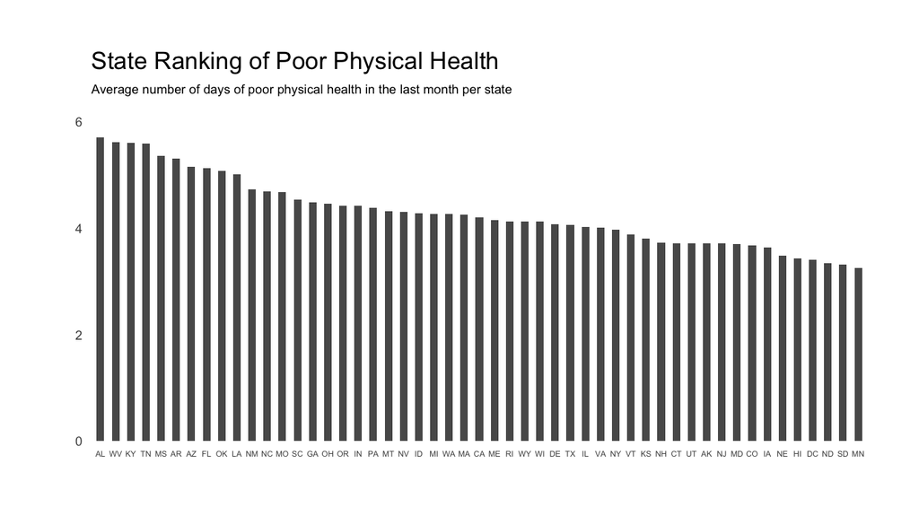

```r
ggplot(statesphlth) +
    geom_bar(aes(x = reorder(State, -Poor_Phys_Hlth_Proportion), y = Poor_Phys_Hlth_Proportion), stat = "identity", width = 0.5) +
    theme(axis.ticks = element_blank(), axis.text.x = element_text(size = rel(0.5), vjust = 10), axis.text.y = element_text(size = rel(0.8)), plot.subtitle = element_text(size = 7), plot.margin = unit(c(1,1,1,1), "cm"), panel.background = element_blank()) +
    xlab(NULL) +
    scale_y_continuous(name = "", limits=c(0, 6)) +
    labs(title = "State Ranking of Poor Physical Health", subtitle = "Average number of days of poor physical health in the last month per state")
```

The results show Alabama had the worst outcome for physical health. Minnesota had the best.

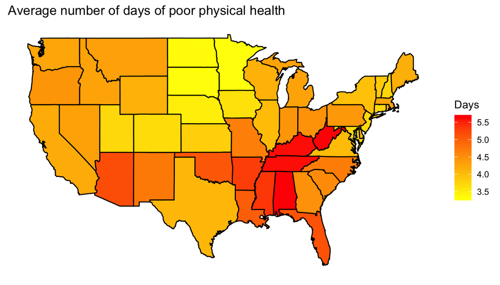

```r
states_map <- map_data("state")

st_names <- st_crosswalk %>%
    rename("State_Name" = "State",
           "State" = "Abb")

states_add <- left_join(statesphlth, st_names, by = "State")

phlthmod <- states_add[, c(5, 2, 3, 4)] %>%
    rename("region" = "State_Name") %>%
    mutate(region = tolower(region))

hlth_map <- left_join(states_map, phlthmod, by = "region")

ggplot(hlth_map, aes(long, lat, group = group)) +
    geom_polygon(aes(fill = Poor_Phys_Hlth_Proportion), color = "black") +
    theme(axis.text.x = element_blank(),
        axis.text.y = element_blank(),
        axis.ticks = element_blank(),
        axis.title.y = element_blank(),
        axis.title.x = element_blank(),
        rect = element_blank()) +
    scale_fill_continuous(name = "Days", low = "yellow", high = "red") +
    labs(title = "Average number of days of poor physical health")
```

```r
brfmhlth <- brfss2013 %>%
    select(X_state, menthlth) %>%
    group_by(X_state) %>%
    summarise(sum(menthlth, na.rm = TRUE))

brfmhlth <- as.data.frame(brfmhlth)

statesmhlthtemp <- merge(brfmhlth, brfstates)

statesmhlth <- statesmhlthtemp[-c(1,2), ]

statesmhlth <- statesmhlth %>%
    rename("State" = "X_state", "Poor_Ment_Hlth" = "sum(menthlth, na.rm = TRUE)", "Total_Records" = "n") %>%
    mutate_at(vars(Poor_Ment_Hlth, Total_Records), as.numeric)

statesmhlth$Poor_Ment_Hlth_Proportion <- (statesmhlth$Poor_Ment_Hlth/statesmhlth$Total_Records)

statesmhlthmerge <- left_join(statesmhlth, st_crosswalk, by = "State")
statesmhlth <- statesmhlthmerge[, c(5, 2, 3, 4)]

statesmhlth <- statesmhlth %>%
    rename(State = Abb) %>%
    filter(State != "GU" & State != "PR") %>%
    arrange(desc(Poor_Ment_Hlth_Proportion))

statesmhlth
```

```
##    State Poor_Ment_Hlth Total_Records Poor_Ment_Hlth_Proportion
## 1     AL          28343          6505                  4.357110
## 2     WV          25535          5899                  4.328700
## 3     KY          46222         10877                  4.249517
## 4     OK          32559          8244                  3.949418
## 5     AR          20138          5268                  3.822703
## 6     MS          28329          7453                  3.801020
## 7     OR          22591          5949                  3.797445
## 8     TN          21952          5815                  3.775064
## 9     CA          42892         11518                  3.723910
## 10    MA          55513         15071                  3.683432
## 11    MO          26011          7118                  3.654257
## 12    FL         122913         33668                  3.650737
## 13    LA          18894          5215                  3.623011
## 14    OH          42923         11971                  3.585582
```

[output cut: 37 more lines]

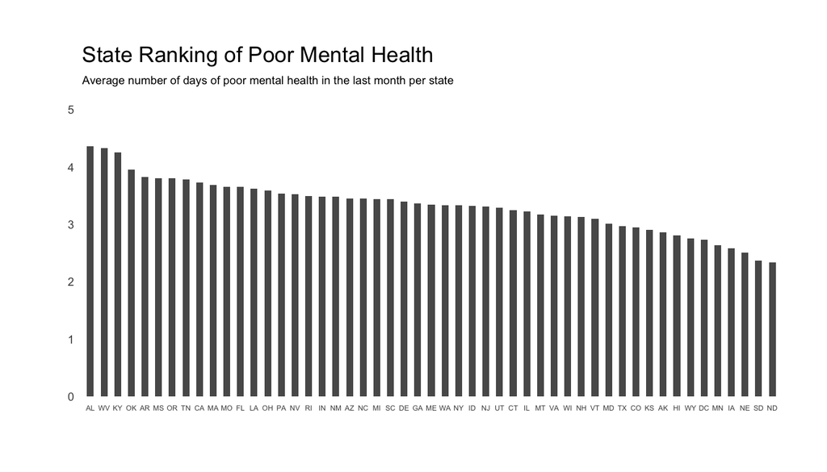

```r
ggplot(statesmhlth) +
    geom_bar(aes(x = reorder(State, -Poor_Ment_Hlth_Proportion), y = Poor_Ment_Hlth_Proportion), stat = "identity", width = 0.5) +
    theme(axis.ticks = element_blank(), axis.text.x = element_text(size = rel(0.5), vjust = 10), axis.text.y = element_text(size = rel(0.8)), plot.subtitle = element_text(size = 7), plot.margin = unit(c(1,1,1,1), "cm"), panel.background = element_blank()) +
    xlab(NULL) +
    scale_y_continuous(name = "", limits=c(0, 5)) +
    labs(title = "State Ranking of Poor Mental Health", subtitle = "Average number of days of poor mental health in the last month per state")
```

The results show Alabama also had the worst outcome for mental health. North Dakota had the best.

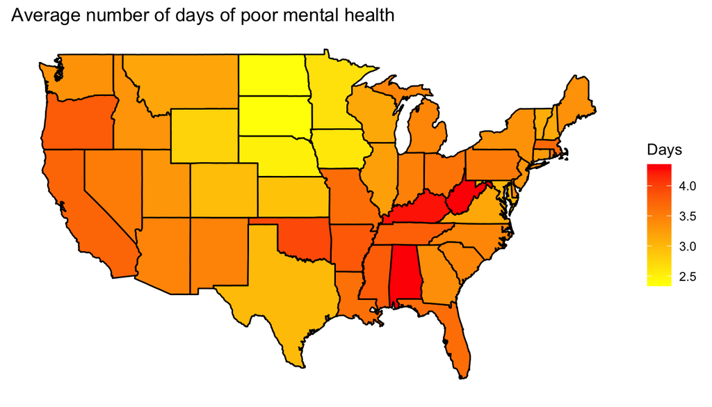

```r
states_add <- left_join(statesmhlth, st_names, by = "State")

mhlthmod <- states_add[, c(5, 2, 3, 4)] %>%
    rename("region" = "State_Name") %>%
    mutate(region = tolower(region))

mhlth_map <- left_join(states_map, mhlthmod, by = "region")

ggplot(mhlth_map, aes(long, lat, group = group)) +
    geom_polygon(aes(fill = Poor_Ment_Hlth_Proportion), color = "black") +
    theme(axis.text.x = element_blank(),
        axis.text.y = element_blank(),
        axis.ticks = element_blank(),
        axis.title.y = element_blank(),
        axis.title.x = element_blank(),
        rect = element_blank()) +
    scale_fill_continuous(name = "Days", low = "yellow", high = "red") +
    labs(title = "Average number of days of poor mental health")
```

**Research quesion 2:** Which states had the highest and lowest proportion of people ages 18-64 without insurance and is there a relationship between having insurance and experiencing poor physical health? (variables: X_state, X_hcvu651, physhlth)

```r
brfins <- brfss2013 %>%
    select(X_state, X_hcvu651) %>%
    group_by(X_state) %>%
    count(X_hcvu651)
brfins <- na.omit(brfins)

noins <- brfins %>%
    filter(X_hcvu651 == "Do not have health care coverage") %>%
    select(X_state, n) %>%
    rename(State = X_state, Total_Uninsured = n)

staterecs <- brfstates %>%
    slice(3:n()-1) %>%
    rename(State = X_state, Total_Records = n)

stateins <- merge(noins, staterecs)

stateinsrank <- stateins %>%
    mutate(Uninsured_Proportion = Total_Uninsured/Total_Records) %>%
    arrange(desc(Uninsured_Proportion))

stateinsabb <- left_join(stateinsrank, st_crosswalk, by = "State")
stateinsabb <- stateinsabb %>%
    rename(State = Abb)

stateinsfinal <- stateinsabb[, c(5, 2, 3, 4)]

stateinsfinal
```

```
##    State Total_Uninsured Total_Records Uninsured_Proportion
## 1     GU             406          1897           0.21402214
## 2     TX            2085         10917           0.19098653
## 3     GA            1344          8658           0.15523216
## 4     NM            1436          9316           0.15414341
## 5     NV             759          5101           0.14879435
## 6     AK             676          4578           0.14766273
## 7     MS            1070          7453           0.14356635
## 8     NC            1258          8860           0.14198646
## 9     WV             832          5899           0.14104085
## 10    ID             766          5630           0.13605684
## 11    AR             712          5268           0.13515566
## 12    CA            1535         11518           0.13326966
## 13    FL            4450         33668           0.13217298
## 14    SC            1350         10717           0.12596809
```

[output cut: 39 more lines]

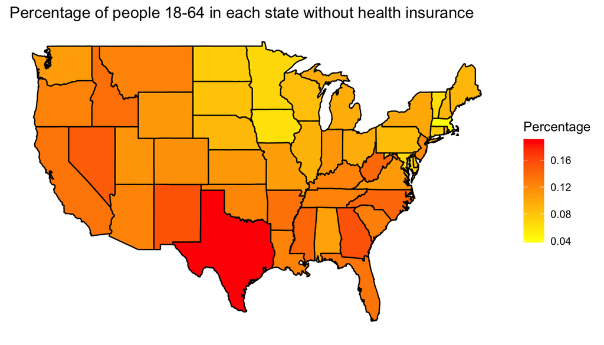

```r
states_map <- map_data("state")

st_names <- st_crosswalk %>%
    rename("State_Name" = "State",
           "State" = "Abb")

states_add <- left_join(stateinsfinal, st_names, by = "State")

insmod <- states_add[, c(5, 2, 3, 4)] %>%
    rename("region" = "State_Name") %>%
    mutate(region = tolower(region))

ins_map <- left_join(states_map, insmod, by = "region")

ggplot(ins_map, aes(long, lat, group = group)) +
    geom_polygon(aes(fill = Uninsured_Proportion), color = "black") +
    theme(axis.text.x = element_blank(),
        axis.text.y = element_blank(),
        axis.ticks = element_blank(),
        axis.title.y = element_blank(),
        axis.title.x = element_blank(),
        rect = element_blank()) +
    scale_fill_continuous(name = "Percentage", low = "yellow", high = "red") +
    labs(title = "Percentage of people 18-64 in each state without health insurance")
```

Texas had the largest share of uninsured residents age 18-64. Massachusetts had the smallest.

```r
inshlth <- left_join(stateinsfinal, statesphlth)
```

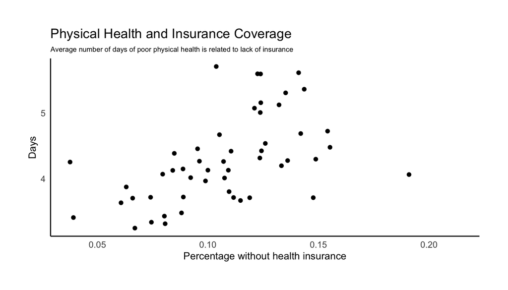

```r
inshlth <- inshlth[, c(1, 3, 2, 4, 5, 6)]

ggplot(inshlth) +
    geom_point(mapping = aes(x = Uninsured_Proportion, y = Poor_Phys_Hlth_Proportion)) +
     theme(axis.ticks = element_blank(), plot.margin = unit(c(1,1,1,1), "cm"), plot.subtitle = element_text(size = 7), axis.title.x = element_text(size = 10), axis.title.y = element_text(size = 10), panel.background = element_blank(), panel.grid.major = element_blank(), panel.grid.minor = element_blank(), axis.line = element_line(colour = "black")) +
    xlab("Percentage without health insurance") +
    ylab("Days") +
    labs(title = "Physical Health and Insurance Coverage", subtitle = "Average number of days of poor physical health is related to lack of insurance")
```

There appears to be a positive relationship between the number of days of poor physical health and not having insurance coverage.

**Research quesion 3:** Do married people have more or fewer number of days of poor mental health? (variables: marital, menthlth)

```r
marmnt <- brfss2013 %>%
    select(marital, menthlth) %>%
    mutate(marital = forcats::fct_explicit_na(marital)) %>%
    group_by(marital) %>%
    summarise(sum(menthlth, na.rm = TRUE))

marcount <- brfss2013 %>%
    select(marital) %>%
    mutate(marital = forcats::fct_explicit_na(marital)) %>%
    count(marital)

marmntmerge <- merge(marmnt, marcount)

marmntmerge <- marmntmerge[-c(1), ]

marmntmerge <- marmntmerge %>%
    rename("Poor_Ment_Hlth" = "sum(menthlth, na.rm = TRUE)", "Total_Records" = "n")
marmntmerge$Poor_Ment_Hlth_Proportion <- (marmntmerge$Poor_Ment_Hlth/marmntmerge$Total_Records)

marmntmerge
```

```
##                           marital Poor_Ment_Hlth Total_Records
## 2 A member of an unmarried couple          58446         13173
## 3                        Divorced         331180         70376
## 4                         Married         646905        253329
## 5                   Never married         313938         75070
## 6                       Separated          74700         10662
## 7                         Widowed         193509         65745
##   Poor_Ment_Hlth_Proportion
## 2                  4.436803
## 3                  4.705866
## 4                  2.553616
## 5                  4.181937
## 6                  7.006190
## 7                  2.943326
```

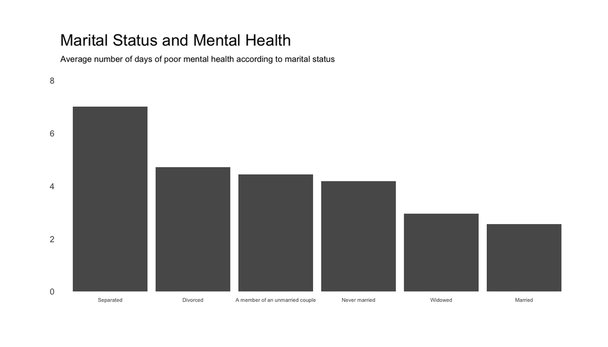

```r
ggplot(marmntmerge) +
    geom_bar(aes(x = reorder(marital, -Poor_Ment_Hlth_Proportion), y = Poor_Ment_Hlth_Proportion), stat = "identity") +
    theme(axis.ticks = element_blank(), axis.text.x = element_text(size = rel(0.5), vjust = 10), axis.text.y = element_text(size = rel(0.8)), plot.subtitle = element_text(size = 7), plot.margin = unit(c(1,1,1,1), "cm"), panel.background = element_blank()) +
    xlab(NULL) +
    scale_y_continuous(name = "", limits=c(0, 8)) +
    labs(title = "Marital Status and Mental Health", subtitle = "Average number of days of poor mental health according to marital status")
```

Separated people have the worst mental health outcomes. Married people have the best.